```python
import pandas as pd
import seaborn as sns
import matplotlib.pyplot as plt
from sklearn.cluster import KMeans
import warnings
warnings.filterwarnings('ignore')
```

# **Load the Data Set**

```python
customer_df = pd.read_csv("C:/Users/emmar/OneDrive/Desktop/Projects/Project 4/Mall_Customers.csv")

# show the first 5 rows
customer_df.head(10)
```

|  | CustomerID | Gender | Age | Annual Income (k$) | Spending Score (1-100) |
| --- | --- | --- | --- | --- | --- |
| 0 | 1 | Male | 19 | 15 | 39 |
| 1 | 2 | Male | 21 | 15 | 81 |
| 2 | 3 | Female | 20 | 16 | 6 |
| 3 | 4 | Female | 23 | 16 | 77 |
| 4 | 5 | Female | 31 | 17 | 40 |
| 5 | 6 | Female | 22 | 17 | 76 |
| 6 | 7 | Female | 35 | 18 | 6 |
| 7 | 8 | Female | 23 | 18 | 94 |
| 8 | 9 | Male | 64 | 19 | 3 |
| 9 | 10 | Female | 30 | 19 | 72 |

# **Univariate Analysis**

**I want to analyze and visualize one variable at a time.**

```python
customer_df.describe()
```

|  | CustomerID | Age | Annual Income (k$) | Spending Score (1-100) |
| --- | --- | --- | --- | --- |
| count | 200.000000 | 200.000000 | 200.000000 | 200.000000 |
| mean | 100.500000 | 38.850000 | 60.560000 | 50.200000 |
| std | 57.879185 | 13.969007 | 26.264721 | 25.823522 |
| min | 1.000000 | 18.000000 | 15.000000 | 1.000000 |
| 25% | 50.750000 | 28.750000 | 41.500000 | 34.750000 |
| 50% | 100.500000 | 36.000000 | 61.500000 | 50.000000 |
| 75% | 150.250000 | 49.000000 | 78.000000 | 73.000000 |
| max | 200.000000 | 70.000000 | 137.000000 | 99.000000 |

I can see the count, mean, standard deviation, and quartiles for each variable using describe. This helps me understand the dataset more and one thing I noticed is that in every variable the mean and median are very close. This tells me that each variable should have a normal distribution and I will visualize the distributions next to confirm.

```python
customer_df.columns
```

```
Index(['CustomerID', 'Gender', 'Age', 'Annual Income (k$)',
       'Spending Score (1-100)'],
      dtype='object')
```

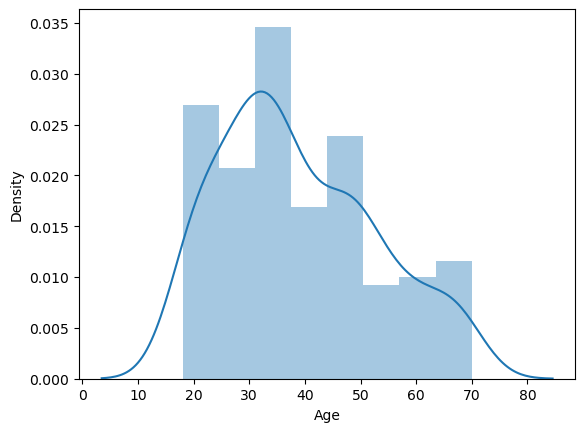

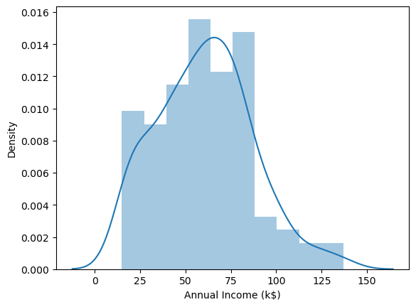

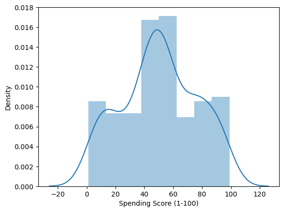

```python
columns = ['Age', 'Annual Income (k$)', 'Spending Score (1-100)']
for i in columns:
    plt.figure()
    sns.distplot(customer_df[i])
```

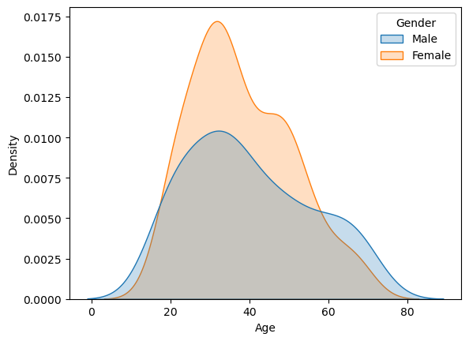

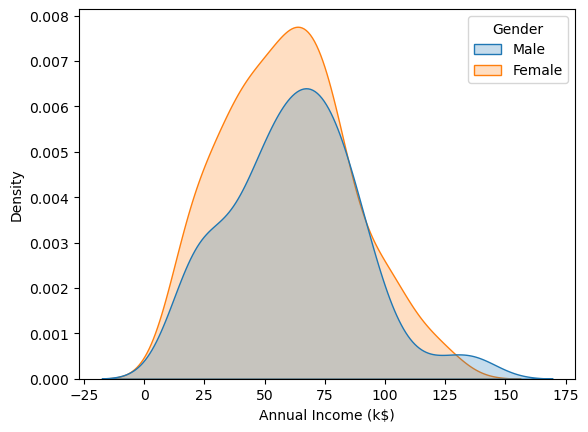

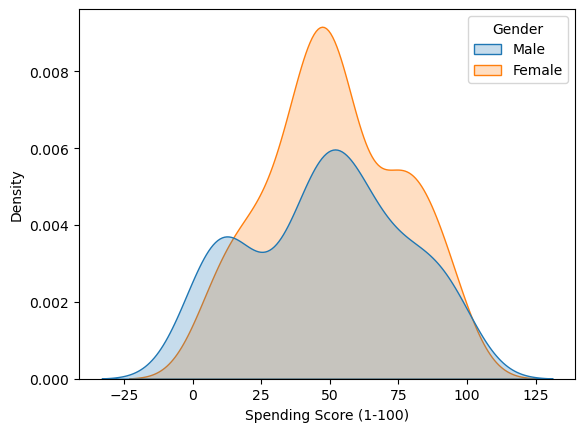

```python
for i in columns:
    plt.figure()
    sns.kdeplot(data=customer_df, x=i, hue='Gender', fill=True)
```

This filter of gender give much more detail to our visualizations and better insights on the mall customers. For example, I can see that between the ages of 20 and 40 there is higher frequency in females. For annual income, between 50k and 80k there is higher frequency in females than males. It also looks like for males there could be an outlier which is suggested by the tail that is formed on the right side. Then looking at spending score, it looks like males have a lower spending score compared to females.

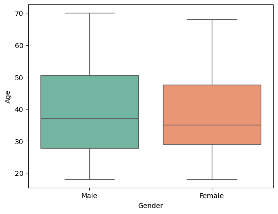

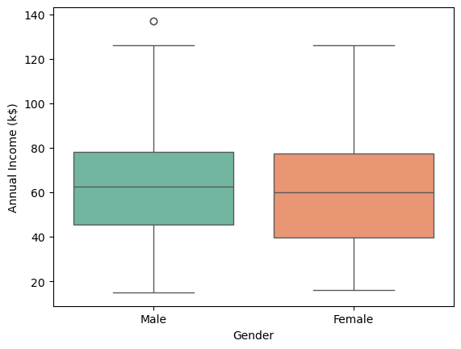

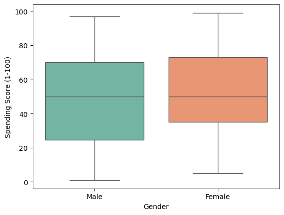

```python
for i in columns:
    plt.figure()
    sns.boxplot(data=customer_df, x='Gender', y=i, palette='Set2')
```

Using boxplots helps me visualize the data in another way. For age I can see that the median is a bit higher compared to females. I can also see that the age in males is more spread out while females is more narrow. The opposite goes for annual income, the median for males is higher but it is most likely due to the outlier and in this boxplot the income is more spread in females than it is in males.

What is interesting in the spending score boxplot is how the median is the same between males and females but the spread is larger in males showing that there are more values in spending scores in males.

```python
customer_df['Gender'].value_counts(normalize=True)
```

```
Gender
Female    0.56
Male      0.44
Name: proportion, dtype: float64
```

**56%** of the customers are **female**, and **44%** of them are **male**.

# **Bivariate Analysis**

**Now I want to look at two variables together.**

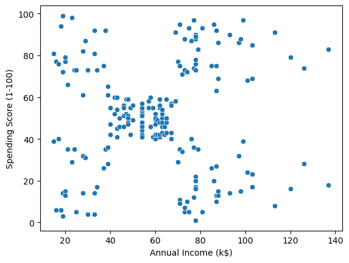

```python
sns.scatterplot(data=customer_df, x='Annual Income (k$)', y= 'Spending Score (1-100)')
```

By looking at the scatterplot I can already see some clustering within the data. It looks like there are about 5 clusters in the scatterplot.

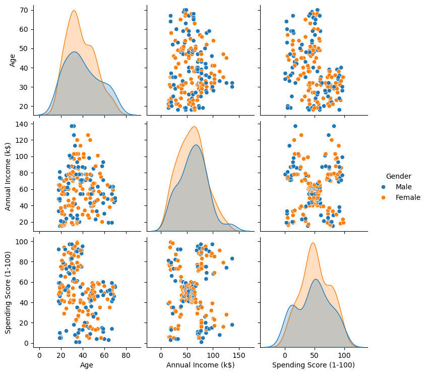

```python
#customer_df = customer_df.drop('CustomerID', axis=1)
sns.pairplot(data=customer_df, hue='Gender')
```

Using pairplot I made it faster and easier to visualize the relationships between my variables. This helps me identify any clusters quickly, I can see that I will benefit from a bivariate clustering between spending score and annual income.

```python
customer_df.groupby(['Gender'])[['Age', 'Annual Income (k$)',
       'Spending Score (1-100)']].mean()
```

| Gender | Age | Annual Income (k$) | Spending Score (1-100) |
| --- | --- | --- | --- |
| Female | 38.098214 | 59.250000 | 51.526786 |
| Male | 39.806818 | 62.227273 | 48.511364 |

I think it is good to know the mean values of my data based on gender. This gives good information where I can see the average age in male and females is similar. Annual income is slightly higher in males, and spending score is a bit higher in females.

```python
customer_df.select_dtypes(include='number').corr()
```

[output not shown]

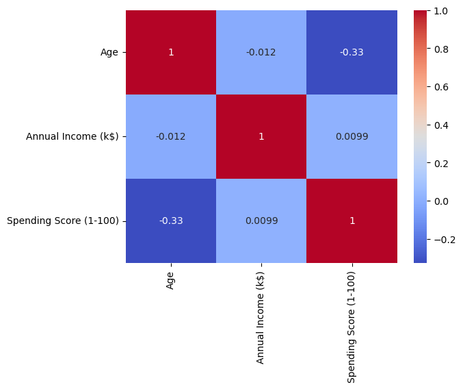

```python
sns.heatmap(customer_df.select_dtypes(include='number').corr(), annot=True, cmap='coolwarm')
```

# **Clustering: Unitvariate, Bivariate, Multivariate**

I want to find the ideal number of clusters.

```python
# starting off KMeans had no parameter, I had to identify the number of clusters was ideal using the elbow method shown below.
clustering1 = KMeans(n_clusters=3)
```

```python
clustering1.fit(customer_df[['Annual Income (k$)']])
```

```
KMeans(n_clusters=3)
```

```python
clustering1.labels_
```

```
array([2, 2, 2, 2, 2, 2, 2, 2, 2, 2, 2, 2, 2, 2, 2, 2, 2, 2, 2, 2, 2, 2,
       2, 2, 2, 2, 2, 2, 2, 2, 2, 2, 2, 2, 2, 2, 2, 2, 2, 2, 2, 2, 2, 2,
       2, 2, 2, 2, 2, 2, 2, 2, 2, 2, 2, 2, 2, 2, 2, 2, 2, 2, 2, 2, 2, 2,
       2, 2, 2, 2, 2, 2, 0, 0, 0, 0, 0, 0, 0, 0, 0, 0, 0, 0, 0, 0, 0, 0,
       0, 0, 0, 0, 0, 0, 0, 0, 0, 0, 0, 0, 0, 0, 0, 0, 0, 0, 0, 0, 0, 0,
       0, 0, 0, 0, 0, 0, 0, 0, 0, 0, 0, 0, 0, 0, 0, 0, 0, 0, 0, 0, 0, 0,
       0, 0, 0, 0, 0, 0, 0, 0, 0, 0, 0, 0, 0, 0, 0, 0, 0, 0, 0, 0, 0, 0,
       0, 0, 0, 0, 0, 0, 0, 0, 0, 0, 1, 1, 1, 1, 1, 1, 1, 1, 1, 1, 1, 1,
       1, 1, 1, 1, 1, 1, 1, 1, 1, 1, 1, 1, 1, 1, 1, 1, 1, 1, 1, 1, 1, 1,
       1, 1], dtype=int32)
```

```python
customer_df['Income Cluster'] = clustering1.labels_
customer_df.head()
```

[output not shown]

```python
customer_df['Income Cluster'].value_counts()
```

```
Income Cluster
0    92
2    72
1    36
Name: count, dtype: int64
```

```python
clustering1.inertia_
```

```
23528.152173913048
```

```python
# using these values I will create a plot for my elbow method to determine how many clusters are ideal
inertia_scores = []
for i in range(1,11):
    kmeans = KMeans(n_clusters=i)
    kmeans.fit(customer_df[['Annual Income (k$)']])
    inertia_scores.append(kmeans.inertia_)
```

```python
inertia_scores
```

```
[137277.28000000003,
 48660.88888888888,
 23517.33093093093,
 14631.886877828052,
 8667.679614837509,
 5430.245925925926,
 3984.6157796451917,
 3365.1402470078942,
 2459.137445887446,
 1914.1893162393162]
```

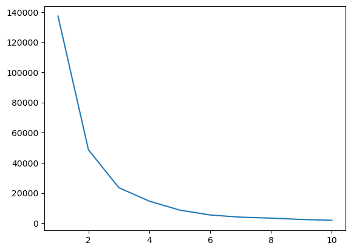

```python
plt.plot(range(1,11), inertia_scores)
```

I can see that the elbow starts at 3, so I will go back to my clustering1 variable and change the parameter.

```python
customer_df.columns
```

```
Index(['Gender', 'Age', 'Annual Income (k$)', 'Spending Score (1-100)',
       'Income Cluster'],
      dtype='object')
```

```python
customer_df.groupby('Income Cluster')[['Age', 'Annual Income (k$)',
       'Spending Score (1-100)']].mean()
```

| Income Cluster | Age | Annual Income (k$) | Spending Score (1-100) |
| --- | --- | --- | --- |
| 0 | 39.184783 | 66.717391 | 50.054348 |
| 1 | 37.833333 | 99.888889 | 50.638889 |
| 2 | 38.930556 | 33.027778 | 50.166667 |

# **Bivariate Clustering**

Now I am doing a bivariate clustering. As I mentioned earlier based on the data, a bivariate clustering would benefit me the most. I also know from my earlier analysis that the ideal number of clusters is 5 but I am still going to double check using the elbow test again.

```python
clustering2 = KMeans(n_clusters=5)
clustering2.fit(customer_df[['Annual Income (k$)', 'Spending Score (1-100)']])
customer_df['Spending and Income Cluster'] = clustering2.labels_
customer_df.head()
```

|  | Gender | Age | Annual Income (k$) | Spending Score (1-100) | Income Cluster | Spending and Income Cluster |
| --- | --- | --- | --- | --- | --- | --- |
| 0 | Male | 19 | 15 | 39 | 2 | 4 |
| 1 | Male | 21 | 15 | 81 | 2 | 0 |
| 2 | Female | 20 | 16 | 6 | 2 | 4 |
| 3 | Female | 23 | 16 | 77 | 2 | 0 |
| 4 | Female | 31 | 17 | 40 | 2 | 4 |

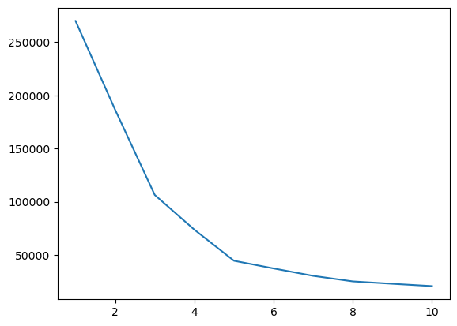

```python
inertia_scores2 = []
for i in range(1,11):
    kmeans2 = KMeans(n_clusters=i)
    kmeans2.fit(customer_df[['Annual Income (k$)', 'Spending Score (1-100)']])
    inertia_scores2.append(kmeans2.inertia_)
plt.plot(range(1,11), inertia_scores2)
```

Looking at the graph I can see my elbow starts at 5, so I can go back to my clustering2 variable and pass 5 as a parameter.

```python
centers_df = pd.DataFrame(clustering2.cluster_centers_)
centers_df.columns = ['x', 'y']
centers_df
```

|  | x | y |
| --- | --- | --- |
| 0 | 25.727273 | 79.363636 |
| 1 | 88.200000 | 17.114286 |
| 2 | 55.296296 | 49.518519 |
| 3 | 86.538462 | 82.128205 |
| 4 | 26.304348 | 20.913043 |

I want to be able to add these centers to my scatterplot to label the centers of my clusters.

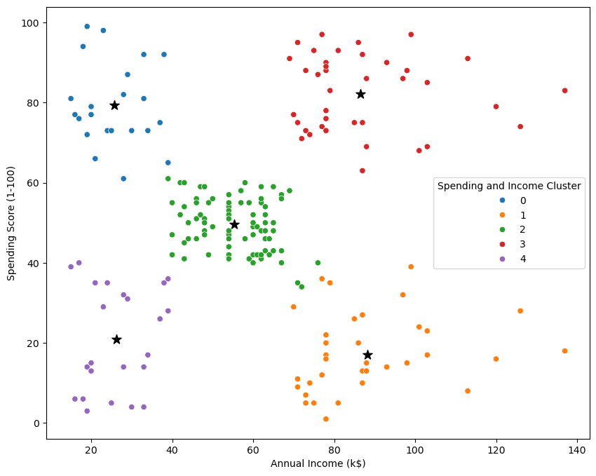

```python
plt.figure(figsize=(10,8))
plt.scatter(x=centers_df['x'], y=centers_df['y'], s=100, c='black', marker='*')
sns.scatterplot(data=customer_df, x='Annual Income (k$)', y= 'Spending Score (1-100)', hue='Spending and Income Cluster',palette='tab10')
```

My target cluster will be cluster 3. The one with high spending score and high annual income. This cluster will bring in the most money. We can look further into this cluster and see what gender dominates as well as what the average age is.

```python
pd.crosstab(customer_df['Spending and Income Cluster'], customer_df['Gender'], normalize='index')
```

| Gender Spending and Income Cluster | Female | Male |
| --- | --- | --- |
| 0 | 0.590909 | 0.409091 |
| 1 | 0.457143 | 0.542857 |
| 2 | 0.592593 | 0.407407 |
| 3 | 0.538462 | 0.461538 |
| 4 | 0.608696 | 0.391304 |

This gives me more detail on the clusters and shows me what gender dominates in each. I can see that in my target cluster females dominate over males. Overall in 4 out of the 5 clusters females dominate. Males only dominate in 1.

```python
customer_df.groupby('Spending and Income Cluster')[['Age', 'Annual Income (k$)',
       'Spending Score (1-100)']].mean()
```

| Spending and Income Cluster | Age | Annual Income (k$) | Spending Score (1-100) |
| --- | --- | --- | --- |
| 0 | 25.272727 | 25.727273 | 79.363636 |
| 1 | 41.114286 | 88.200000 | 17.114286 |
| 2 | 42.716049 | 55.296296 | 49.518519 |
| 3 | 32.692308 | 86.538462 | 82.128205 |
| 4 | 45.217391 | 26.304348 | 20.913043 |

Here I can see that the average age in my target cluster is 33, the average annual income is 87k, and the average spending score is 82.

# **Multivariate Clustering**

```python
from sklearn.preprocessing import StandardScaler
```

```python
scale = StandardScaler()
```

```python
customer_df.head()
```

|  | Gender | Age | Annual Income (k$) | Spending Score (1-100) | Income Cluster | Spending and Income Cluster |
| --- | --- | --- | --- | --- | --- | --- |
| 0 | Male | 19 | 15 | 39 | 2 | 4 |
| 1 | Male | 21 | 15 | 81 | 2 | 0 |
| 2 | Female | 20 | 16 | 6 | 2 | 4 |
| 3 | Female | 23 | 16 | 77 | 2 | 0 |
| 4 | Female | 31 | 17 | 40 | 2 | 4 |

```python
new_df = pd.get_dummies(customer_df, drop_first=True, dtype=int)
new_df.head()
```

|  | Age | Annual Income (k$) | Spending Score (1-100) | Income Cluster | Spending and Income Cluster | Gender_Male |
| --- | --- | --- | --- | --- | --- | --- |
| 0 | 19 | 15 | 39 | 2 | 4 | 1 |
| 1 | 21 | 15 | 81 | 2 | 0 | 1 |
| 2 | 20 | 16 | 6 | 2 | 4 | 0 |
| 3 | 23 | 16 | 77 | 2 | 0 | 0 |
| 4 | 31 | 17 | 40 | 2 | 4 | 0 |

```python
new_df = new_df[['Age', 'Annual Income (k$)', 'Spending Score (1-100)', 'Gender_Male']]
new_df.head()
```

|  | Age | Annual Income (k$) | Spending Score (1-100) | Gender_Male |
| --- | --- | --- | --- | --- |
| 0 | 19 | 15 | 39 | 1 |
| 1 | 21 | 15 | 81 | 1 |
| 2 | 20 | 16 | 6 | 0 |
| 3 | 23 | 16 | 77 | 0 |
| 4 | 31 | 17 | 40 | 0 |

```python
new_df = pd.DataFrame(scale.fit_transform(new_df))
new_df.head()
```

|  | 0 | 1 | 2 | 3 |
| --- | --- | --- | --- | --- |
| 0 | -1.424569 | -1.738999 | -0.434801 | 1.128152 |
| 1 | -1.281035 | -1.738999 | 1.195704 | 1.128152 |
| 2 | -1.352802 | -1.700830 | -1.715913 | -0.886405 |
| 3 | -1.137502 | -1.700830 | 1.040418 | -0.886405 |
| 4 | -0.563369 | -1.662660 | -0.395980 | -0.886405 |

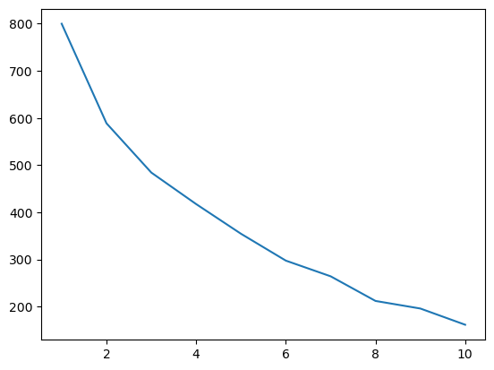

```python
inertia_scores3 = []
for i in range(1,11):
    kmeans3 = KMeans(n_clusters=i)
    kmeans3.fit(new_df)
    inertia_scores3.append(kmeans3.inertia_)
plt.plot(range(1,11), inertia_scores3)
```

I can create a scatterplot but I won't because I think that the bivariate scatterplot gives me great information.